# Lab Session 2 - 1.5 Hours

- Before each epoch, shuffle the training set.
- Print the loss per mini batch and the training/validation accuracy per epoch. (Display results every 100 epochs)
- Save the model after training
- Print after training the final testing accuracy

```python
from time import time
```

```python
# Initializing the variables
init = tf.global_variables_initializer()
# Create a summary to monitor cost tensor
tf.summary.scalar("Loss_LeNet-5_SGD", cost)
# Create a summary to monitor accuracy tensor
tf.summary.scalar("Accuracy_LeNet-5_SGD", acc)
# Merge all summaries into a single op
merged_summary_op = tf.summary.merge_all()

display_step = 1

# Initializing the variables
def train(init, sess, logs_path, n_epochs, batch_size, optimizer, cost, merged_summary_op):
    # optimizer and cost are the same kinds of objects as in Section 1
    # Train your model
    sess.run(init)
    # op to write logs to Tensorboard
    summary_writer = tf.summary.FileWriter(logs_path, graph=tf.get_default_graph())

    x_val, y_val = mnist.validation.images.reshape(-1, 28, 28, 1), mnist.validation.labels
    x_test, y_test = mnist.test.images.reshape(-1, 28, 28, 1), mnist.test.labels

    t0 = time()
    # Training cycle
    for epoch in range(n_epochs):
        avg_cost = 0.
        total_batch = int(mnist.train.num_examples/batch_size)
        # Loop over all batches
        for i in range(total_batch):
            batch_xs, batch_ys = mnist.train.next_batch(batch_size, shuffle=(i==0))
            batch_xs = batch_xs.reshape(-1, 28, 28, 1)
            # Run optimization op (backprop), cost op (to get loss value)
            # and summary nodes
            _, c, summary = sess.run([optimizer, cost, merged_summary_op],
                                     feed_dict={x: batch_xs, y: batch_ys})
            # Write logs at every iteration
            summary_writer.add_summary(summary, epoch * total_batch + i)
            # Compute average loss
            avg_cost += c / total_batch

        # Accuracies
        acc_val = acc.eval({x: x_val, y:y_val})
        acc_test = acc.eval({x: x_test, y:y_test})

        # Display logs per epoch step
        if (epoch+1) % display_step == 0:
            print(
                "Epoch: ", '%02d' % (epoch+1),
                "  =====> Loss=", "{:.9f}".format(avg_cost),
                "  =====> Validation accuracy=", "{:.2f} %".format(acc_val * 100),
                "  =====> Test accuracy=", "{:.2f}%".format(acc_test * 100)
            )

    print("Optimization Finished!")
    summary_writer.flush()

    # Print the accuracy on testing data
    print("Training Time: ", time()-t0, "s")
    print("Test accuracy= {:.2f}%".format(acc.eval({x: x_test, y:y_test}) * 100))
```

```python
with tf.Session() as sess:
    train(init, sess, logs_path, training_epochs, batch_size, optimizer, cost, merged_summary_op)
```

```
Epoch:  01   =====> Loss= 2.278514425   =====> Validation accuracy= 15.10 %   =====> Test accuracy= 14.72%
Epoch:  02   =====> Loss= 2.248564847   =====> Validation accuracy= 24.10 %   =====> Test accuracy= 23.58%
Epoch:  03   =====> Loss= 2.194563249   =====> Validation accuracy= 33.94 %   =====> Test accuracy= 32.99%
Epoch:  04   =====> Loss= 2.075531592   =====> Validation accuracy= 52.38 %   =====> Test accuracy= 51.22%
Epoch:  05   =====> Loss= 1.761539334   =====> Validation accuracy= 71.62 %   =====> Test accuracy= 70.99%
Epoch:  06   =====> Loss= 1.170879033   =====> Validation accuracy= 79.38 %   =====> Test accuracy= 80.96%
Epoch:  07   =====> Loss= 0.758031500   =====> Validation accuracy= 83.22 %   =====> Test accuracy= 84.19%
Epoch:  08   =====> Loss= 0.583518426   =====> Validation accuracy= 85.62 %   =====> Test accuracy= 86.58%
Epoch:  09   =====> Loss= 0.491530831   =====> Validation accuracy= 87.94 %   =====> Test accuracy= 88.43%
Epoch:  10   =====> Loss= 0.432062764   =====> Validation accuracy= 89.60 %   =====> Test accuracy= 89.54%
Epoch:  11   =====> Loss= 0.390086841   =====> Validation accuracy= 90.62 %   =====> Test accuracy= 90.25%
Epoch:  12   =====> Loss= 0.359332046   =====> Validation accuracy= 91.16 %   =====> Test accuracy= 90.90%
Epoch:  13   =====> Loss= 0.335538126   =====> Validation accuracy= 91.58 %   =====> Test accuracy= 91.36%
Epoch:  14   =====> Loss= 0.316699791   =====> Validation accuracy= 92.00 %   =====> Test accuracy= 91.62%
Epoch:  15   =====> Loss= 0.300946029   =====> Validation accuracy= 92.12 %   =====> Test accuracy= 92.10%
Epoch:  16   =====> Loss= 0.287274962   =====> Validation accuracy= 92.66 %   =====> Test accuracy= 92.55%
Epoch:  17   =====> Loss= 0.275803425   =====> Validation accuracy= 92.90 %   =====> Test accuracy= 92.76%
Epoch:  18   =====> Loss= 0.265697270   =====> Validation accuracy= 93.10 %   =====> Test accuracy= 93.03%
Epoch:  19   =====> Loss= 0.256185688   =====> Validation accuracy= 93.28 %   =====> Test accuracy= 93.18%
Epoch:  20   =====> Loss= 0.247560531   =====> Validation accuracy= 93.60 %   =====> Test accuracy= 93.32%
Epoch:  21   =====> Loss= 0.240320395   =====> Validation accuracy= 93.74 %   =====> Test accuracy= 93.52%
Epoch:  22   =====> Loss= 0.232987639   =====> Validation accuracy= 93.88 %   =====> Test accuracy= 93.68%
Epoch:  23   =====> Loss= 0.226582186   =====> Validation accuracy= 93.98 %   =====> Test accuracy= 93.72%
Epoch:  24   =====> Loss= 0.220531708   =====> Validation accuracy= 94.16 %   =====> Test accuracy= 93.90%
Epoch:  25   =====> Loss= 0.214747677   =====> Validation accuracy= 94.38 %   =====> Test accuracy= 94.04%
Epoch:  26   =====> Loss= 0.209260124   =====> Validation accuracy= 94.56 %   =====> Test accuracy= 94.12%
Epoch:  27   =====> Loss= 0.204082473   =====> Validation accuracy= 94.74 %   =====> Test accuracy= 94.32%
Epoch:  28   =====> Loss= 0.199223248   =====> Validation accuracy= 94.80 %   =====> Test accuracy= 94.46%
Epoch:  29   =====> Loss= 0.194851020   =====> Validation accuracy= 94.90 %   =====> Test accuracy= 94.58%
Epoch:  30   =====> Loss= 0.190322321   =====> Validation accuracy= 95.08 %   =====> Test accuracy= 94.75%
Epoch:  31   =====> Loss= 0.186385711   =====> Validation accuracy= 95.22 %   =====> Test accuracy= 94.93%
Epoch:  32   =====> Loss= 0.182291276   =====> Validation accuracy= 95.22 %   =====> Test accuracy= 95.10%
Epoch:  33   =====> Loss= 0.178567867   =====> Validation accuracy= 95.30 %   =====> Test accuracy= 95.13%
Epoch:  34   =====> Loss= 0.174958918   =====> Validation accuracy= 95.40 %   =====> Test accuracy= 95.14%
Epoch:  35   =====> Loss= 0.171474084   =====> Validation accuracy= 95.56 %   =====> Test accuracy= 95.24%
Epoch:  36   =====> Loss= 0.168226188   =====> Validation accuracy= 95.54 %   =====> Test accuracy= 95.49%
Epoch:  37   =====> Loss= 0.164982525   =====> Validation accuracy= 95.56 %   =====> Test accuracy= 95.45%
Epoch:  38   =====> Loss= 0.162006176   =====> Validation accuracy= 95.72 %   =====> Test accuracy= 95.57%
Epoch:  39   =====> Loss= 0.159158580   =====> Validation accuracy= 95.82 %   =====> Test accuracy= 95.70%
Epoch:  40   =====> Loss= 0.156510202   =====> Validation accuracy= 95.90 %   =====> Test accuracy= 95.72%
Optimization Finished!
Training Time:  812.2784585952759 s
Test accuracy= 95.72%
```

**Question 2.1.6** : Use TensorBoard to visualise and save loss and accuracy curves. You will save figures in the folder **"lab_2/MNIST_figures"** and display them in your notebook.

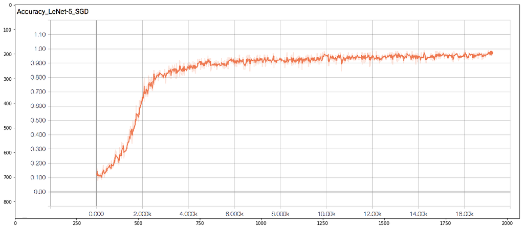

```python
import matplotlib.image as mpimg
import matplotlib.pyplot as plt
%matplotlib inline

plt.figure(figsize=(20,20))
img = mpimg.imread('MNIST_figures/Accuracy_LeNet-5_SGD.png')
imgplot = plt.imshow(img)
plt.show()
```

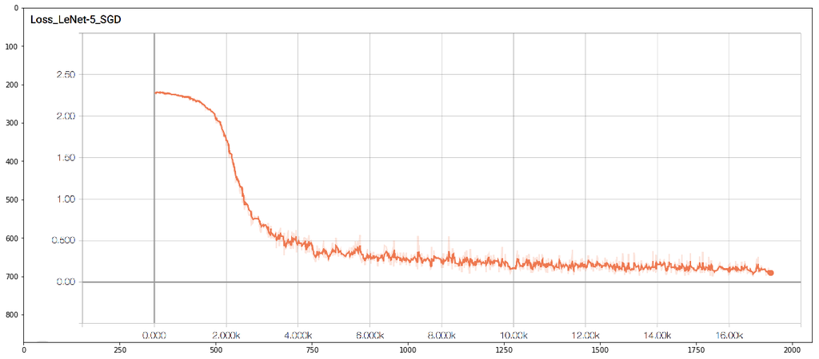

```python
plt.figure(figsize=(20,20))
img = mpimg.imread('MNIST_figures/Loss_LeNet-5_SGD.png')
imgplot = plt.imshow(img)
plt.show()
```

**Part 2** : LeNET 5 Optimization

**Question 2.2.1**

- Retrain your network with AdamOptimizer and then fill the table above:

[output not shown]

- Which optimizer gives the best accuracy on test data?

**Your answer:** AdamOptimizer is the optimizer giving the best accuracy on test data. It reaches $99.05 \%$ at the second last epochs. In terms of time, the difference is not much.

```python
tf.reset_default_graph() # reset the default graph before defining a new model

# tf Graph Input:  mnist data image of shape 28*28=784
x = tf.placeholder(tf.float32, [None, 28, 28, 1], name='InputData')
# 0-9 digits recognition,  10 classes
y = tf.placeholder(tf.float32, [None, 10], name='LabelData')

# Construct model and encapsulating all ops into scopes, making Tensorboard's Graph visualization more convenient
with tf.name_scope('Model'):
    # Model
    pred = LeNet5_Model(x) # Softmax
with tf.name_scope('Loss'):
    # Minimize error using cross entropy
    # We use tf.clip_by_value to avoid having too low numbers in the log function
    cost = tf.reduce_mean(-tf.reduce_sum(y*tf.log(tf.clip_by_value(pred, epsilon, 1.0)), reduction_indices=1))
with tf.name_scope('AdamOptimizer'):
    # Gradient Descent
    optimizer = tf.train.AdamOptimizer(learning_rate).minimize(cost)
with tf.name_scope('Accuracy'):
    # Accuracy
    acc = tf.equal(tf.argmax(pred, 1), tf.argmax(y, 1))
    acc = tf.reduce_mean(tf.cast(acc, tf.float32))

# Initializing the variables
init = tf.global_variables_initializer()
# Create a summary to monitor cost tensor
tf.summary.scalar("Loss_LeNet-5_AdamOptimizer", cost)
# Create a summary to monitor accuracy tensor
tf.summary.scalar("Accuracy_LeNet-5_AdamOptimizer", acc)
# Merge all summaries into a single op
merged_summary_op = tf.summary.merge_all()

with tf.Session() as sess:
    train(init, sess, logs_path, training_epochs, batch_size, optimizer, cost, merged_summary_op)
```

```
Epoch:  01   =====> Loss= 0.335209463   =====> Validation accuracy= 96.74 %   =====> Test accuracy= 96.55%
Epoch:  02   =====> Loss= 0.089615537   =====> Validation accuracy= 97.80 %   =====> Test accuracy= 97.88%
Epoch:  03   =====> Loss= 0.064844994   =====> Validation accuracy= 97.96 %   =====> Test accuracy= 98.31%
Epoch:  04   =====> Loss= 0.050338433   =====> Validation accuracy= 98.22 %   =====> Test accuracy= 98.54%
Epoch:  05   =====> Loss= 0.041135502   =====> Validation accuracy= 98.30 %   =====> Test accuracy= 98.45%
Epoch:  06   =====> Loss= 0.034317805   =====> Validation accuracy= 98.76 %   =====> Test accuracy= 98.74%
Epoch:  07   =====> Loss= 0.027801045   =====> Validation accuracy= 98.82 %   =====> Test accuracy= 98.83%
Epoch:  08   =====> Loss= 0.023904629   =====> Validation accuracy= 98.62 %   =====> Test accuracy= 98.69%
Epoch:  09   =====> Loss= 0.020648544   =====> Validation accuracy= 98.26 %   =====> Test accuracy= 98.10%
Epoch:  10   =====> Loss= 0.018754511   =====> Validation accuracy= 98.64 %   =====> Test accuracy= 98.74%
Epoch:  11   =====> Loss= 0.018436432   =====> Validation accuracy= 98.78 %   =====> Test accuracy= 98.93%
Epoch:  12   =====> Loss= 0.016739237   =====> Validation accuracy= 98.68 %   =====> Test accuracy= 98.92%
Epoch:  13   =====> Loss= 0.013478099   =====> Validation accuracy= 98.58 %   =====> Test accuracy= 98.70%
Epoch:  14   =====> Loss= 0.011442503   =====> Validation accuracy= 98.92 %   =====> Test accuracy= 98.95%
Epoch:  15   =====> Loss= 0.010422006   =====> Validation accuracy= 98.84 %   =====> Test accuracy= 98.86%
Epoch:  16   =====> Loss= 0.010230908   =====> Validation accuracy= 98.96 %   =====> Test accuracy= 98.96%
Epoch:  17   =====> Loss= 0.008078704   =====> Validation accuracy= 98.82 %   =====> Test accuracy= 98.81%
Epoch:  18   =====> Loss= 0.007552284   =====> Validation accuracy= 98.74 %   =====> Test accuracy= 98.85%
Epoch:  19   =====> Loss= 0.007115598   =====> Validation accuracy= 98.40 %   =====> Test accuracy= 98.58%
Epoch:  20   =====> Loss= 0.008743658   =====> Validation accuracy= 98.38 %   =====> Test accuracy= 98.57%
Epoch:  21   =====> Loss= 0.007349253   =====> Validation accuracy= 98.50 %   =====> Test accuracy= 98.71%
Epoch:  22   =====> Loss= 0.005872466   =====> Validation accuracy= 98.80 %   =====> Test accuracy= 98.68%
Epoch:  23   =====> Loss= 0.005943254   =====> Validation accuracy= 98.80 %   =====> Test accuracy= 98.56%
Epoch:  24   =====> Loss= 0.006855939   =====> Validation accuracy= 99.02 %   =====> Test accuracy= 98.84%
Epoch:  25   =====> Loss= 0.005796643   =====> Validation accuracy= 98.98 %   =====> Test accuracy= 98.85%
Epoch:  26   =====> Loss= 0.003280939   =====> Validation accuracy= 98.96 %   =====> Test accuracy= 98.87%
Epoch:  27   =====> Loss= 0.005050968   =====> Validation accuracy= 98.94 %   =====> Test accuracy= 98.84%
Epoch:  28   =====> Loss= 0.006697592   =====> Validation accuracy= 98.90 %   =====> Test accuracy= 98.94%
Epoch:  29   =====> Loss= 0.006233852   =====> Validation accuracy= 98.80 %   =====> Test accuracy= 98.91%
Epoch:  30   =====> Loss= 0.003976699   =====> Validation accuracy= 99.04 %   =====> Test accuracy= 99.08%
Epoch:  31   =====> Loss= 0.004583098   =====> Validation accuracy= 98.78 %   =====> Test accuracy= 98.73%
Epoch:  32   =====> Loss= 0.004352974   =====> Validation accuracy= 99.00 %   =====> Test accuracy= 98.94%
Epoch:  33   =====> Loss= 0.003390362   =====> Validation accuracy= 99.04 %   =====> Test accuracy= 98.93%
Epoch:  34   =====> Loss= 0.003543474   =====> Validation accuracy= 99.00 %   =====> Test accuracy= 98.75%
Epoch:  35   =====> Loss= 0.005214187   =====> Validation accuracy= 99.04 %   =====> Test accuracy= 98.96%
Epoch:  36   =====> Loss= 0.003257929   =====> Validation accuracy= 99.04 %   =====> Test accuracy= 98.84%
Epoch:  37   =====> Loss= 0.003991033   =====> Validation accuracy= 98.90 %   =====> Test accuracy= 98.89%
Epoch:  38   =====> Loss= 0.003373141   =====> Validation accuracy= 99.14 %   =====> Test accuracy= 98.99%
Epoch:  39   =====> Loss= 0.002746629   =====> Validation accuracy= 99.18 %   =====> Test accuracy= 99.05%
Epoch:  40   =====> Loss= 0.004838748   =====> Validation accuracy= 99.04 %   =====> Test accuracy= 98.84%
Optimization Finished!
Training Time:  802.6540694236755 s
Test accuracy= 98.84%
```

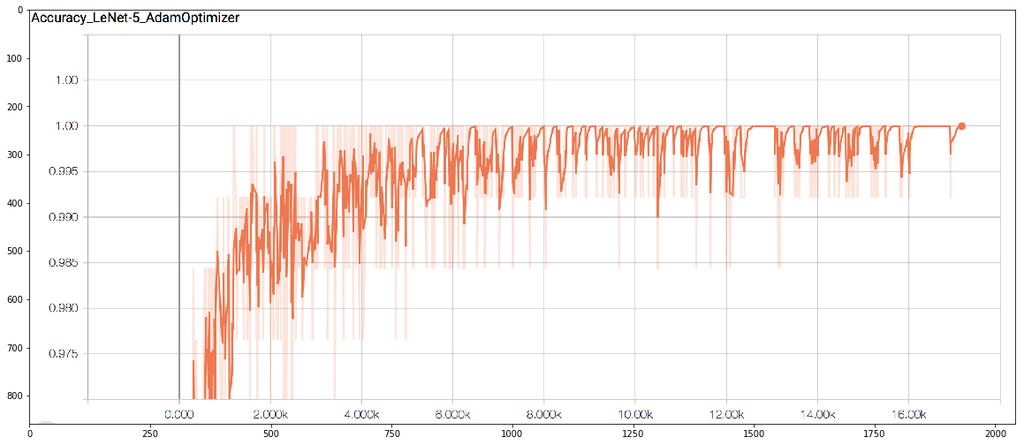

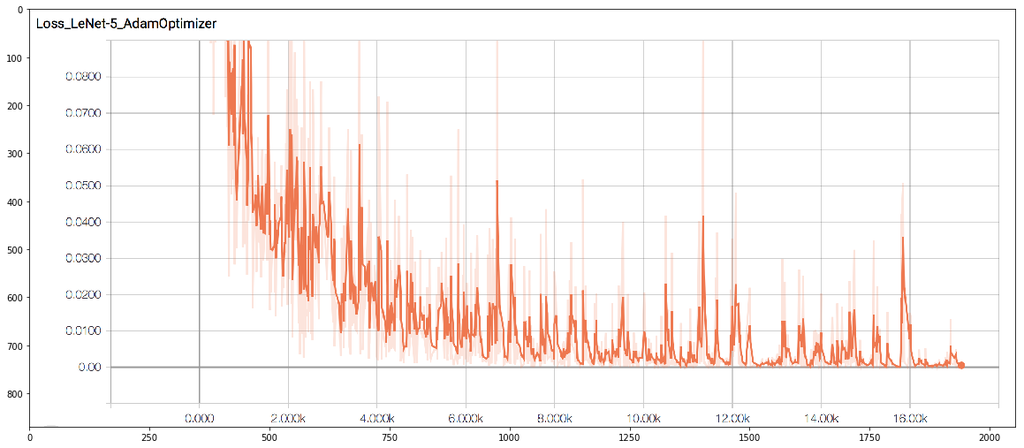

```python
plt.figure(figsize=(20,20))
img = mpimg.imread('MNIST_figures/Accuracy_LeNet-5_AdamOptimizer.png')
imgplot = plt.imshow(img)
plt.show()

plt.figure(figsize=(20,20))
img = mpimg.imread('MNIST_figures/Loss_LeNet-5_AdamOptimizer.png')
imgplot = plt.imshow(img)
plt.show()
```

**Question 2.2.2** Try to add dropout (keep_prob = 0.75) before the first fully connected layer. You will use tf.nn.dropout for that purpose. What accuracy do you achieve on testing data?

**Accuracy achieved on testing data:** We achieved an accuracy of $98.91 \%$ which is the best we got until now and it's almost $99 \%$ accuracy. In terms of time, as always, not much difference. Maybe if we stop the loop just after getting a $99 \%$ accuracy on test data, they'll be remarkable difference. In addition, we tried to run the whole notebook again and we got sometimes a convergence to $99 \%$ accuracy in about $22$ iterations which almost less than a half iterations which will reduce so much time. Anyway, we got almost the accuracy we wanted.

```python
def LeNet5_Model_Dropout(image, keep_prob=1.):
    # Layer 1:
    # Convolution (5x5): The output shape should be 28x28x6.
    conv1_weight = weight_variable([5,5,1,6])
    conv1_bias = bias_variable([6])
    conv1 = tf.nn.conv2d(image, conv1_weight, strides = [1,1,1,1], padding = 'SAME') + conv1_bias
    # Activation: ReLU.
    activation1 = tf.nn.relu(conv1)
    # MaxPooling: The output shape should be 14x14x6.
    layer1 = tf.nn.max_pool(activation1, ksize = [1,2,2,1], strides = [1,2,2,1], padding = 'VALID')


    # Layer 2:
    # Convolution (5x5): The output shape should be 10x10x16.
    conv2_weight = weight_variable([5,5,6,16])
    conv2_bias = bias_variable([16])
    conv2 = tf.nn.conv2d(layer1, conv2_weight, strides = [1,1,1,1], padding = 'VALID') + conv2_bias
    # Activation: ReLU.
    activation2 = tf.nn.relu(conv2)
    # MaxPooling: The output shape should be 5x5x16.
    layer2 = tf.nn.max_pool(activation2, ksize = [1,2,2,1], strides = [1,2,2,1], padding = 'VALID')

    # Flatten: Flatten the output shape of the final pooling layer such that it's 1D instead of 3D.
    flatten_v = flatten(layer2)

    # Try to add dropout (keep_prob) before the first fully connected layer.
    flatten_v = tf.nn.dropout(x=flatten_v, keep_prob=keep_prob)

    # Layer 3:
    # Fully Connected: This should have 120 outputs.
    fc3_weight = weight_variable((400, 120))
    fc3_bias = bias_variable([120])
    fc3 = tf.matmul(flatten_v, fc3_weight) + fc3_bias
    # Activation: ReLU
    layer3 = tf.nn.relu(fc3)

    # Layer 4:
    # Fully Connected: This should have 84 outputs.
    fc4_weight = weight_variable((120, 84))
    fc4_bias = bias_variable([84])
    fc4 = tf.matmul(layer3, fc4_weight) + fc4_bias
    # Activation: ReLU
    layer4 = tf.nn.relu(fc4)

    # Layer 5:
    # Fully Connected: This should have 10 outputs
    fc5_weight = weight_variable((84, 10))
    fc5_bias = bias_variable([10])
    fc5 = tf.matmul(layer4, fc5_weight) + fc5_bias
    # Activation: softmax
    layer5 = tf.nn.softmax(fc5)

    return layer5
```

```python
tf.reset_default_graph() # reset the default graph before defining a new model

# tf Graph Input:  mnist data image of shape 28*28=784
x = tf.placeholder(tf.float32, [None, 28, 28, 1], name='InputData')
# 0-9 digits recognition,  10 classes
y = tf.placeholder(tf.float32, [None, 10], name='LabelData')

# Construct model and encapsulating all ops into scopes, making Tensorboard's Graph visualization more convenient
with tf.name_scope('Model'):
    # Model
    pred = LeNet5_Model_Dropout(x, keep_prob=0.75) # Softmax
with tf.name_scope('Loss'):
    # Minimize error using cross entropy
    # We use tf.clip_by_value to avoid having too low numbers in the log function
    cost = tf.reduce_mean(-tf.reduce_sum(y*tf.log(tf.clip_by_value(pred, epsilon, 1.0)), reduction_indices=1))
with tf.name_scope('AdamOptimizer'):
    # Gradient Descent
    optimizer = tf.train.AdamOptimizer(learning_rate).minimize(cost)
with tf.name_scope('Accuracy'):
    # Accuracy
    acc = tf.equal(tf.argmax(pred, 1), tf.argmax(y, 1))
    acc = tf.reduce_mean(tf.cast(acc, tf.float32))

# Initializing the variables
init = tf.global_variables_initializer()
# Create a summary to monitor cost tensor
tf.summary.scalar("Loss_LeNet-5_AdamOptimizer-Dropout", cost)
# Create a summary to monitor accuracy tensor
tf.summary.scalar("Accuracy_LeNet-5_AdamOptimizer-Dropout", acc)
# Merge all summaries into a single op
merged_summary_op = tf.summary.merge_all()

with tf.Session() as sess:
    train(init, sess, logs_path, training_epochs, batch_size, optimizer, cost, merged_summary_op)
```

```
Epoch:  01   =====> Loss= 0.368667226   =====> Validation accuracy= 96.22 %   =====> Test accuracy= 96.17%
Epoch:  02   =====> Loss= 0.114180280   =====> Validation accuracy= 97.24 %   =====> Test accuracy= 97.27%
Epoch:  03   =====> Loss= 0.084118124   =====> Validation accuracy= 97.80 %   =====> Test accuracy= 97.56%
Epoch:  04   =====> Loss= 0.070988952   =====> Validation accuracy= 98.26 %   =====> Test accuracy= 98.39%
Epoch:  05   =====> Loss= 0.060844921   =====> Validation accuracy= 98.58 %   =====> Test accuracy= 98.44%
Epoch:  06   =====> Loss= 0.053007241   =====> Validation accuracy= 98.42 %   =====> Test accuracy= 98.42%
Epoch:  07   =====> Loss= 0.047189861   =====> Validation accuracy= 98.66 %   =====> Test accuracy= 98.28%
Epoch:  08   =====> Loss= 0.042888786   =====> Validation accuracy= 98.82 %   =====> Test accuracy= 98.50%
Epoch:  09   =====> Loss= 0.038664355   =====> Validation accuracy= 98.88 %   =====> Test accuracy= 98.53%
Epoch:  10   =====> Loss= 0.035251468   =====> Validation accuracy= 98.92 %   =====> Test accuracy= 98.70%
Epoch:  11   =====> Loss= 0.033487975   =====> Validation accuracy= 98.54 %   =====> Test accuracy= 98.72%
Epoch:  12   =====> Loss= 0.031398230   =====> Validation accuracy= 98.78 %   =====> Test accuracy= 98.51%
Epoch:  13   =====> Loss= 0.029382045   =====> Validation accuracy= 98.96 %   =====> Test accuracy= 98.71%
Epoch:  14   =====> Loss= 0.029087619   =====> Validation accuracy= 98.88 %   =====> Test accuracy= 98.71%
Epoch:  15   =====> Loss= 0.026585564   =====> Validation accuracy= 98.66 %   =====> Test accuracy= 98.72%
Epoch:  16   =====> Loss= 0.024069790   =====> Validation accuracy= 98.74 %   =====> Test accuracy= 98.83%
Epoch:  17   =====> Loss= 0.022549898   =====> Validation accuracy= 98.76 %   =====> Test accuracy= 98.83%
Epoch:  18   =====> Loss= 0.021138982   =====> Validation accuracy= 98.78 %   =====> Test accuracy= 98.89%
Epoch:  19   =====> Loss= 0.022163949   =====> Validation accuracy= 98.68 %   =====> Test accuracy= 98.86%
Epoch:  20   =====> Loss= 0.019419505   =====> Validation accuracy= 98.92 %   =====> Test accuracy= 98.96%
Epoch:  21   =====> Loss= 0.018217808   =====> Validation accuracy= 98.66 %   =====> Test accuracy= 98.43%
Epoch:  22   =====> Loss= 0.020181028   =====> Validation accuracy= 98.94 %   =====> Test accuracy= 98.86%
Epoch:  23   =====> Loss= 0.016691845   =====> Validation accuracy= 98.80 %   =====> Test accuracy= 98.66%
Epoch:  24   =====> Loss= 0.017606126   =====> Validation accuracy= 98.76 %   =====> Test accuracy= 98.87%
Epoch:  25   =====> Loss= 0.015426494   =====> Validation accuracy= 98.88 %   =====> Test accuracy= 98.88%
Epoch:  26   =====> Loss= 0.016024023   =====> Validation accuracy= 98.64 %   =====> Test accuracy= 98.78%
Epoch:  27   =====> Loss= 0.015150604   =====> Validation accuracy= 98.96 %   =====> Test accuracy= 98.80%
Epoch:  28   =====> Loss= 0.012979869   =====> Validation accuracy= 98.70 %   =====> Test accuracy= 98.82%
Epoch:  29   =====> Loss= 0.013189316   =====> Validation accuracy= 98.86 %   =====> Test accuracy= 98.66%
Epoch:  30   =====> Loss= 0.014361240   =====> Validation accuracy= 98.86 %   =====> Test accuracy= 98.83%
Epoch:  31   =====> Loss= 0.013187178   =====> Validation accuracy= 98.68 %   =====> Test accuracy= 98.73%
Epoch:  32   =====> Loss= 0.013940939   =====> Validation accuracy= 98.92 %   =====> Test accuracy= 98.88%
Epoch:  33   =====> Loss= 0.013117311   =====> Validation accuracy= 98.82 %   =====> Test accuracy= 98.76%
Epoch:  34   =====> Loss= 0.012013112   =====> Validation accuracy= 98.98 %   =====> Test accuracy= 98.90%
Epoch:  35   =====> Loss= 0.010725909   =====> Validation accuracy= 98.80 %   =====> Test accuracy= 98.93%
Epoch:  36   =====> Loss= 0.012581934   =====> Validation accuracy= 98.82 %   =====> Test accuracy= 98.95%
Epoch:  37   =====> Loss= 0.010165876   =====> Validation accuracy= 98.68 %   =====> Test accuracy= 98.75%
Epoch:  38   =====> Loss= 0.011711903   =====> Validation accuracy= 98.78 %   =====> Test accuracy= 98.66%
Epoch:  39   =====> Loss= 0.009171836   =====> Validation accuracy= 98.82 %   =====> Test accuracy= 99.03%
Epoch:  40   =====> Loss= 0.012259223   =====> Validation accuracy= 98.86 %   =====> Test accuracy= 98.92%
Optimization Finished!
Training Time:  813.3592414855957 s
Test accuracy= 98.91%
```

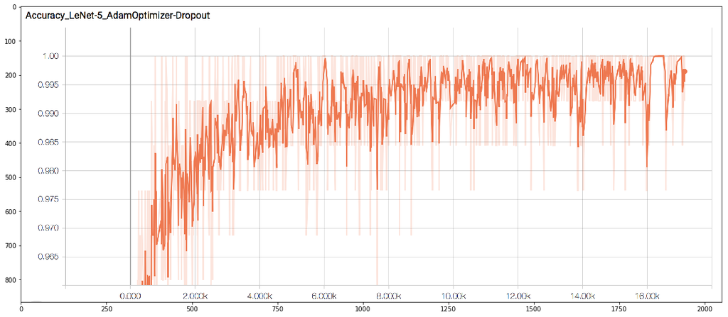

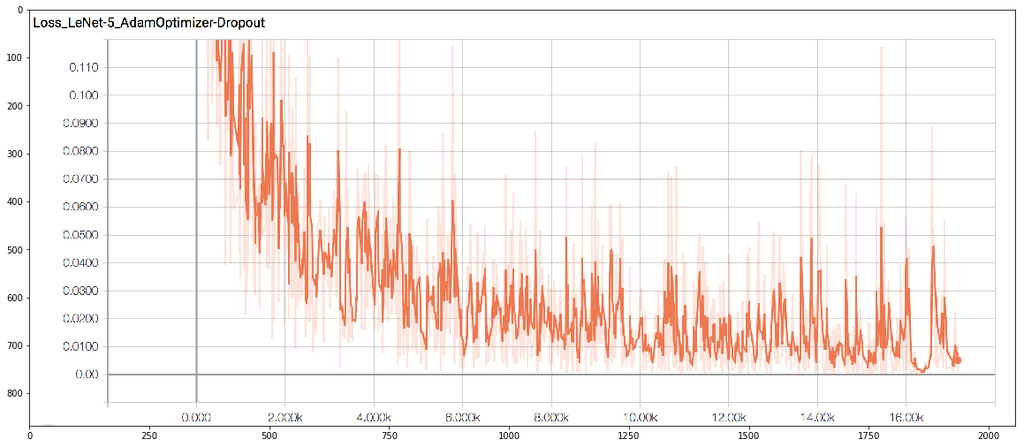

```python
plt.figure(figsize=(20,20))
img = mpimg.imread('MNIST_figures/Accuracy_LeNet-5_AdamOptimizer-Dropout.png')
imgplot = plt.imshow(img)
plt.show()

plt.figure(figsize=(20,20))
img = mpimg.imread('MNIST_figures/Loss_LeNet-5_AdamOptimizer-Dropout.png')
imgplot = plt.imshow(img)
plt.show()
```